# PSTAT131_Final

### Variable kidney_disease

- First, draw a plot of variable kidney_disease

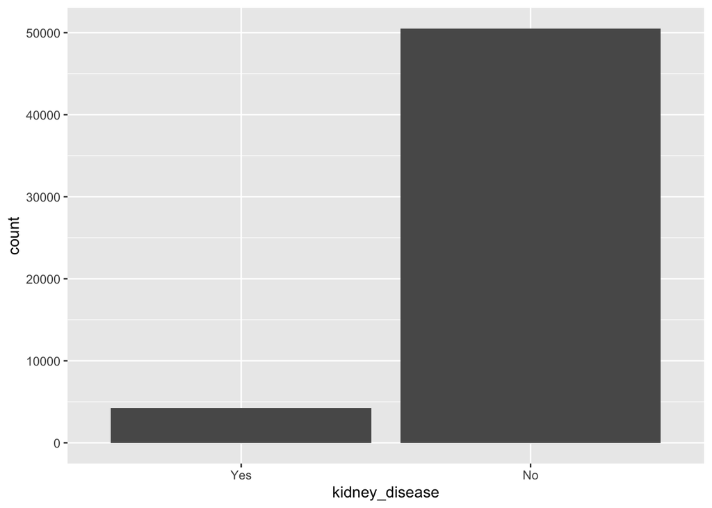

```r
newrecords %>%
  ggplot(aes(x = kidney_disease)) +
  geom_bar()
```

- According to the graph, we find that there are much more observations on ‘No’ levels than ‘Yes’ levels for variable `kidney_disease`.For this reason, it maybe hard for us to find the relationship between `kidney_disease` and `heart_disease`.
- Second, draw a plot of variable `kidney_disease` by `heart_disease`

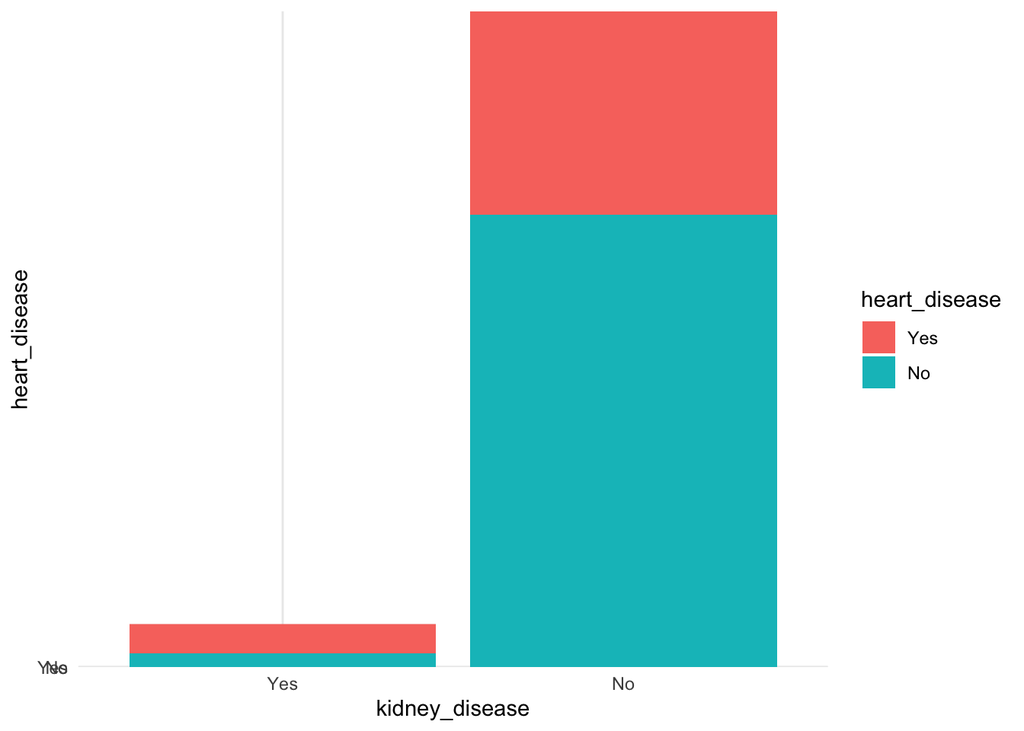

```r
newrecords %>%
  ggplot(aes(x= kidney_disease, y= heart_disease , fill= heart_disease)) +
  geom_bar(stat="identity")+theme_minimal()
```

* Based on the graph, we can find that the respondent who had kidney_disease is more likely to get heart disease. ( We will confirm this result at the end of this project )

### Variable skin_cancer

- First, draw a plot of variable skin_cancer

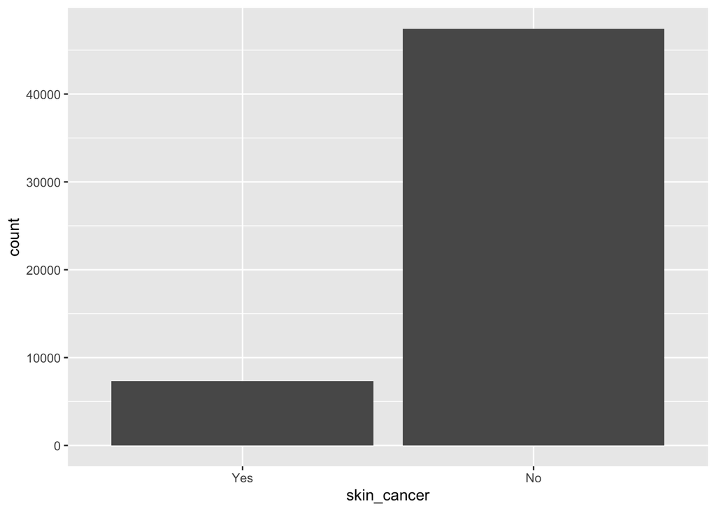

```r
newrecords %>%
  ggplot(aes(x = skin_cancer)) +
  geom_bar()
```

- According to the graph, we find that there are much more observations on ‘No’ levels than ‘Yes’ levels for variable `skin_cancer`.For this reason, it maybe hard for us to find the relationship between `skin_cancer` and `heart_disease`.
- Second, draw a plot of variable `skin_cancer` by `heart_disease`

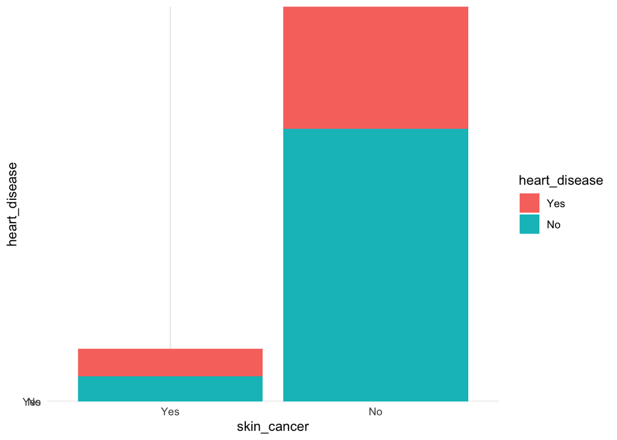

```r
newrecords %>%
  ggplot(aes(x= skin_cancer, y= heart_disease , fill= heart_disease)) +
  geom_bar(stat="identity")+theme_minimal()
```

- Based on the graph, we can find that the respondent who had skin_cancer is more likely to get heart disease. ( We will confirm this result at the end of this project )

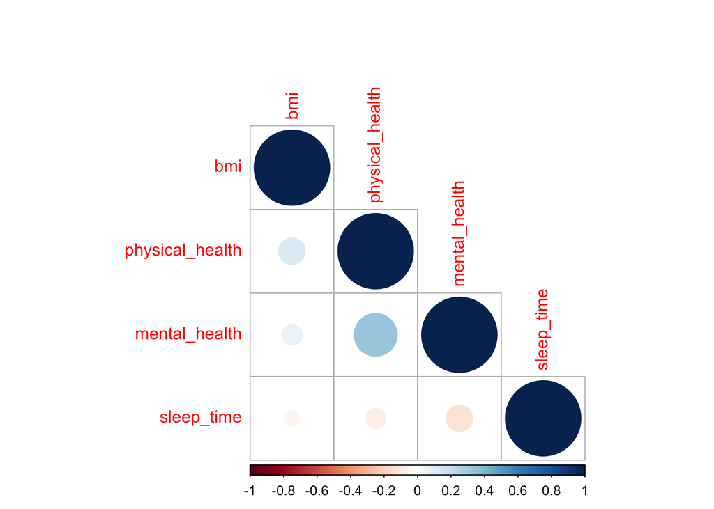

```r
newrecords %>%
  select(is.numeric) %>%
  cor() %>%
  corrplot(type = "lower")
```

## Data Split

```r
set.seed(1234)
newrecords_split <- newrecords %>%
  initial_split(prop = 0.8, strata = "heart_disease")

newrecords_train <- training(newrecords_split)
newrecords_test <- testing(newrecords_split)
```

```r
# check whether the training and testing data sets
# have the appropriate number of observations.
dim(newrecords)
```

```
## [1] 54760    18
```

```r
dim(newrecords_train)
```

```
## [1] 43807    18
```

```r
dim(newrecords_test)
```

```
## [1] 10953    18
```

## Model Fitting

In this part, I decided to use 4 different model classes (6 models in total).

- Class 1: Logistic regression, LDA and QDA
- Class 2: Boosted tree
- Class 3: Random forest
- Class 4: Nearest Neighbors

### Building the Recipe

```r
recipe <- recipe(
  heart_disease ~ smoking+ alcohol_drinking+ stroke,physical_health+ mental_health+diff_walking+sex+age_category+race+diabetic+physical_activity+gen_health+sleep_time+asthma+kidney_disease+skin_cancer, data = newrecords_train) %>%
  step_dummy(all_nominal_predictors()) %>%
  step_center(all_predictors()) %>%
  step_scale(all_predictors())
```

### Uses cross-validation to fold training set.

- We use v-fold cross-validation on the training set. Use 5 folds.
- We stratify the folds by heart_disease as well.
- Stratifying the folds can be useful since it can makes sure the distribution of a heart_disease (often the outcome) remains the same across resamples or, in cross-validation, across folds.

```r
newrecords_folds <- vfold_cv(data = newrecords_train, v = 5, strata = heart_disease )
```

### Class 1: Logistic regression, LDA and QDA

Since these three models belong to the same model class, we want to select the best model among the three models to represent the best model in this class. We will finally use the four models from 4 different classes to select the best model of the four model classes as our final model.

#### Logistic regression

We specify a logistic regression model for classification using the “glm” engine. Then create a workflow. After that, we add model and the appropriate recipe (we created before).

```r
log_reg <- logistic_reg() %>%
  set_engine("glm") %>%
  set_mode("classification")

log_wkflow <- workflow() %>%
  add_model(log_reg) %>%
  add_recipe(recipe)
```

#### LDA

In a similar process, but this time specify a linear discriminant analysis model for classification using the “MASS” engine.

```r
lda_mod <- discrim_linear() %>%
  set_mode("classification") %>%
  set_engine("MASS")

lda_wkflow <- workflow() %>%
  add_model(lda_mod) %>%
  add_recipe(recipe)
```

#### QDA

In a similar process, but this time specify a quadratic discriminant analysis model for classification using the “MASS” engine.

```r
qda_mod <- discrim_quad() %>%
  set_mode("classification") %>%
  set_engine("MASS")

qda_wkflow <- workflow() %>%
  add_model(qda_mod) %>%
  add_recipe(recipe)
```

#### Assess the performance of each of these three models

- Fit each of the models created before to the folded data.

```r
control <- control_resamples(save_pred = TRUE)

log_fit <- fit_resamples(log_wkflow, newrecords_folds)

lda_fit <- fit_resamples(resamples = newrecords_folds,
                         lda_wkflow,
                         control = control)

qda_fit <- fit_resamples(qda_wkflow, resamples = newrecords_folds,
                         control = control)
```

```r
collect_metrics(log_fit)
```

```
## # A tibble: 2 × 6
##   .metric  .estimator  mean     n std_err .config
##   <chr>    <chr>      <dbl> <int>   <dbl> <chr>
## 1 accuracy binary     0.627     5 0.00261 Preprocessor1_Model1
## 2 roc_auc  binary     0.650     5 0.00285 Preprocessor1_Model1
```

```r
collect_metrics(lda_fit)
```

```
## # A tibble: 2 × 6
##   .metric  .estimator  mean     n std_err .config
##   <chr>    <chr>      <dbl> <int>   <dbl> <chr>
## 1 accuracy binary     0.627     5 0.00261 Preprocessor1_Model1
## 2 roc_auc  binary     0.651     5 0.00301 Preprocessor1_Model1
```

```r
collect_metrics(qda_fit)
```

```
## # A tibble: 2 × 6
##   .metric  .estimator  mean     n  std_err .config
##   <chr>    <chr>      <dbl> <int>    <dbl> <chr>
## 1 accuracy binary     0.567     5 0.000244 Preprocessor1_Model1
## 2 roc_auc  binary     0.650     5 0.00213  Preprocessor1_Model1
```

Based on the results we get here, we can see that these three models have very similar standard error of the accuracy (and the differences between them are very small). Since the mean accuracy of the Logistic regression equals to the mean accuracy of the LDA and both are higher than the mean accuracy of QDA, we know that logistic regression and LDA are better than QDA. However, since the LDA model also has the highest mean roc_auc value in these three models. We can conclude that LDA is the best model in these three models.

- Now that we’ve chosen a model, fit our chosen model to the entire training dataset (not to the folds).

```r
lda_fit_train <- fit(lda_wkflow, newrecords_train)
```

- Finally, with your fitted model, use predict(), bind_cols(), and accuracy() to assess your model’s performance on the testing data!

```r
lda_test <- fit(lda_wkflow, newrecords_test)
predict(lda_test, new_data = newrecords_test, type = "class") %>%
  bind_cols(newrecords_test %>% select(heart_disease)) %>%
  accuracy(truth = heart_disease, estimate = .pred_class)
```

```
## # A tibble: 1 × 3
##   .metric  .estimator .estimate
##   <chr>    <chr>          <dbl>
## 1 accuracy binary         0.622
```

#### Confusion matrix, ROC curve and AUC values

Now, using the testing data, we want to create a confusion matrix and visualize it. Plot an ROC curve and calculate the area under it (AUC).

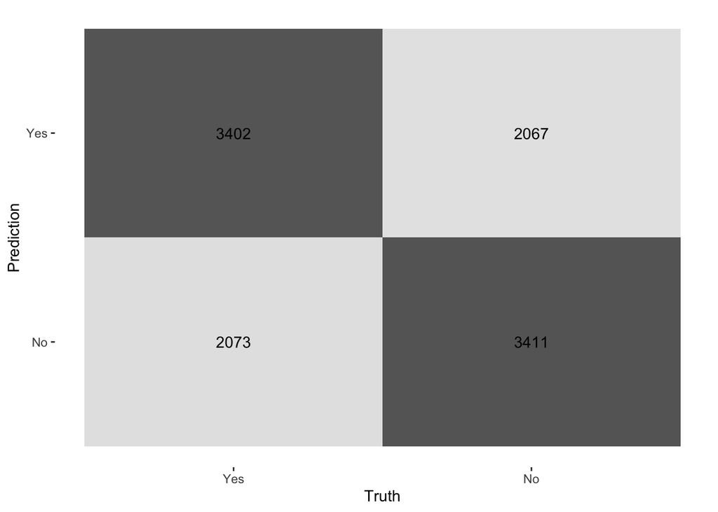

```r
#  create a confusion matrix and visualize it
augment(lda_test, new_data = newrecords_test) %>%
  conf_mat(truth = heart_disease, estimate = .pred_class) %>%
  autoplot(type = "heatmap")
```

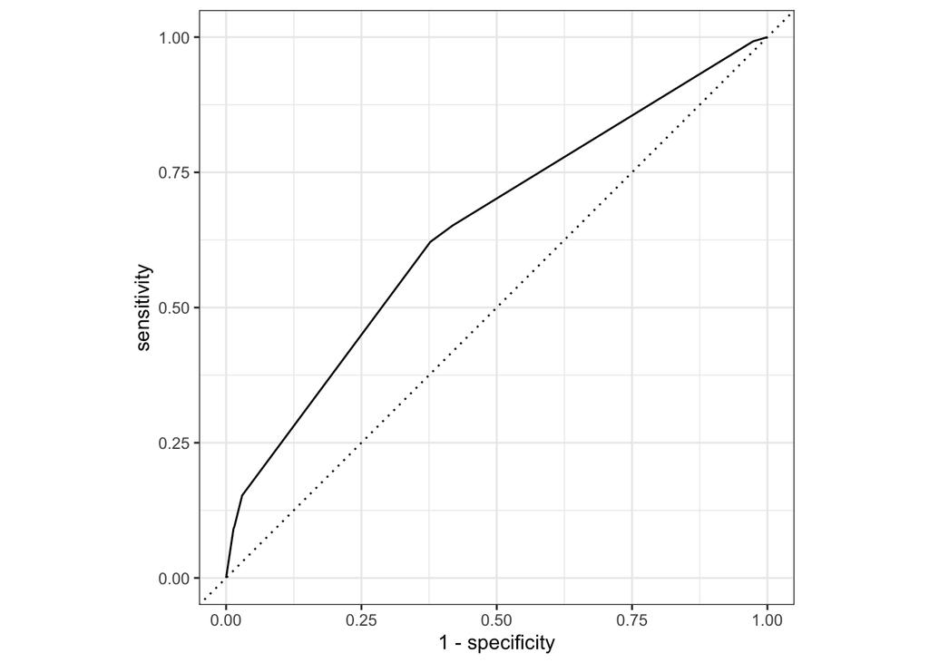

```r
# Plot roc_curve
augment(lda_test, new_data = newrecords_test) %>%
  roc_curve(heart_disease, .pred_Yes) %>%
  autoplot()
```

```r
# Calculate AUC
augment(lda_test, new_data = newrecords_test) %>%
  roc_auc(heart_disease, .pred_Yes)
```

```
## # A tibble: 1 × 3
##   .metric .estimator .estimate
##   <chr>   <chr>          <dbl>
## 1 roc_auc binary         0.646
```

Based on the results, we find that although LDA is the best among the 3 models, it is still not good enough. We want to see if there is a model work better than LDA in other model class.

### Class 2 : Boosted tree